# BreastCancerData

# DATA TRAINNING

```python
from sklearn.model_selection import train_test_split

x_train, x_test, y_train, y_test = train_test_split(x,y, test_size = 0.3,
                                                    random_state=1)
```

```python
x_train
```

|  | radius_mean | texture_mean | perimeter_mean | area_mean | smoothness_mean | compactness_mean | concavity_mean | concave points_mean | symmetry_mean | fractal_dimension_mean | ... | radius_worst | texture_worst | perimeter_worst | area_worst | smoothness_worst | compactness_worst | concavity_worst | concave points_worst | symmetry_worst | fractal_dimension_worst |
| --- | --- | --- | --- | --- | --- | --- | --- | --- | --- | --- | --- | --- | --- | --- | --- | --- | --- | --- | --- | --- | --- |
| 249 | 11.52 | 14.93 | 73.87 | 406.3 | 0.10130 | 0.07808 | 0.043280 | 0.029290 | 0.1883 | 0.06168 | ... | 12.65 | 21.19 | 80.88 | 491.8 | 0.13890 | 0.15820 | 0.180400 | 0.09608 | 0.2664 | 0.07809 |
| 58 | 13.05 | 19.31 | 82.61 | 527.2 | 0.08060 | 0.03789 | 0.000692 | 0.004167 | 0.1819 | 0.05501 | ... | 14.23 | 22.25 | 90.24 | 624.1 | 0.10210 | 0.06191 | 0.001845 | 0.01111 | 0.2439 | 0.06289 |
| 476 | 14.20 | 20.53 | 92.41 | 618.4 | 0.08931 | 0.11080 | 0.050630 | 0.030580 | 0.1506 | 0.06009 | ... | 16.45 | 27.26 | 112.10 | 828.5 | 0.11530 | 0.34290 | 0.251200 | 0.13390 | 0.2534 | 0.07858 |
| 529 | 12.07 | 13.44 | 77.83 | 445.2 | 0.11000 | 0.09009 | 0.037810 | 0.027980 | 0.1657 | 0.06608 | ... | 13.45 | 15.77 | 86.92 | 549.9 | 0.15210 | 0.16320 | 0.162200 | 0.07393 | 0.2781 | 0.08052 |
| 422 | 11.61 | 16.02 | 75.46 | 408.2 | 0.10880 | 0.11680 | 0.070970 | 0.044970 | 0.1886 | 0.06320 | ... | 12.64 | 19.67 | 81.93 | 475.7 | 0.14150 | 0.21700 | 0.230200 | 0.11050 | 0.2787 | 0.07427 |
| ... | ... | ... | ... | ... | ... | ... | ... | ... | ... | ... | ... | ... | ... | ... | ... | ... | ... | ... | ... | ... | ... |
| 129 | 19.79 | 25.12 | 130.40 | 1192.0 | 0.10150 | 0.15890 | 0.254500 | 0.114900 | 0.2202 | 0.06113 | ... | 22.63 | 33.58 | 148.70 | 1589.0 | 0.12750 | 0.38610 | 0.567300 | 0.17320 | 0.3305 | 0.08465 |
| 144 | 10.75 | 14.97 | 68.26 | 355.3 | 0.07793 | 0.05139 | 0.022510 | 0.007875 | 0.1399 | 0.05688 | ... | 11.95 | 20.72 | 77.79 | 441.2 | 0.10760 | 0.12230 | 0.097550 | 0.03413 | 0.2300 | 0.06769 |
| 72 | 17.20 | 24.52 | 114.20 | 929.4 | 0.10710 | 0.18300 | 0.169200 | 0.079440 | 0.1927 | 0.06487 | ... | 23.32 | 33.82 | 151.60 | 1681.0 | 0.15850 | 0.73940 | 0.656600 | 0.18990 | 0.3313 | 0.13390 |
| 235 | 14.03 | 21.25 | 89.79 | 603.4 | 0.09070 | 0.06945 | 0.014620 | 0.018960 | 0.1517 | 0.05835 | ... | 15.33 | 30.28 | 98.27 | 715.5 | 0.12870 | 0.15130 | 0.062310 | 0.07963 | 0.2226 | 0.07617 |
| 37 | 13.03 | 18.42 | 82.61 | 523.8 | 0.08983 | 0.03766 | 0.025620 | 0.029230 | 0.1467 | 0.05863 | ... | 13.30 | 22.81 | 84.46 | 545.9 | 0.09701 | 0.04619 | 0.048330 | 0.05013 | 0.1987 | 0.06169 |

398 rows × 30 columns

```python
y_test
```

```
421    0
47     1
292    0
186    1
414    1
      ..
6      1
487    1
11     1
268    0
419    0
Name: diagnosis, Length: 171, dtype: int64
```

```python
print('x-train shape : ', x_train.shape)
print('y-train shape : ', y_train.shape)
print('x-test shape : ', x_test.shape)
print('y-test shape : ', y_test.shape)
```

```
x-train shape :  (398, 30)
y-train shape :  (398,)
x-test shape :  (171, 30)
y-test shape :  (171,)
```

# K-Nearest Neighbour (KNN)

```python
from sklearn.neighbors import KNeighborsClassifier
knn = KNeighborsClassifier(n_neighbors =3)
knn.fit(x_train, y_train)
predicted_value = knn.predict (x_test)
correct_value= np.array (y_test)

print ('KNN(with k=3 ) accuracy is: ', knn.score(x_test, y_test))
```

```
KNN(with k=3 ) accuracy is:  0.9239766081871345
```

```
best k for Knn : 7 , best accuracy : 0.935672514619883
```

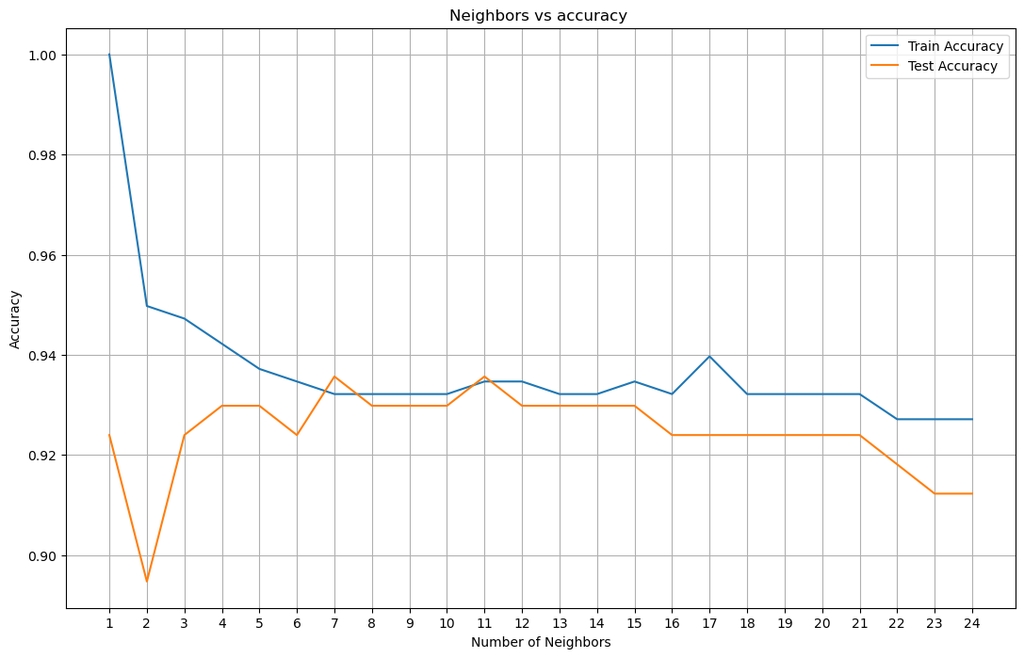

```python
# find best n value for knn
best_neig= range(1,25)
train_accuracy_list =[]
test_accuracy_list =[]

for each in best_neig:
    knn = KNeighborsClassifier(n_neighbors =each)
    knn.fit(x_train,  y_train)
    train_accuracy_list.append( knn.score(x_train, y_train))
    test_accuracy_list.append( knn.score(x_test, y_test))


print( 'best k for Knn : {} , best accuracy : {}'.format(test_accuracy_list.index(np.max(test_accuracy_list))+1, np.max(test_accuracy_list)))
plt.figure(figsize=[13,8])
plt.plot(best_neig, train_accuracy_list,label = 'Train Accuracy')
plt.plot(best_neig, test_accuracy_list,label = 'Test Accuracy')
plt.title('Neighbors vs accuracy ')
plt.xlabel('Number of Neighbors')
plt.ylabel('Accuracy')
plt.legend()
plt.grid()
plt.xticks(best_neig)
plt.show()
```

```python
print( 'best k for Knn : {} , best accuracy : {}'.format(test_accuracy_list.index(np.max(test_accuracy_list))+1, np.max(test_accuracy_list)))
```

```
best k for Knn : 7 , best accuracy : 0.935672514619883
```

# TRAINING OF MODEL USING SUPPORT VECTOR MACHINE CLASSIFICATION

```python
from sklearn.svm import SVC
svm = SVC(random_state = 1, gamma='auto')
svm.fit(x_train, y_train)
print ("accuraccy of SVM : ", svm.score(x_test, y_test))
```

```
accuraccy of SVM :  0.631578947368421
```

# USING NAIVE BAYES

```python
from sklearn.naive_bayes import GaussianNB
nb = GaussianNB()
nb.fit(x_train, y_train)
print ("accuracy of naive bayes: ", nb.score(x_test, y_test))
```

```
accuracy of naive bayes:  0.9473684210526315
```

# USING DECISION TREE CLASSIFICATION

```python
#Decision Tree
from sklearn.tree import DecisionTreeClassifier
dt = DecisionTreeClassifier()
dt.fit(x_train, y_train)
print ("accuracy of Decision Tree Classification: ", dt.score(x_test, y_test))
```

```
accuracy of Decision Tree Classification:  0.9473684210526315
```

# RANDOM FOREST CLASSIFICATION

```python
#Random Forest
from sklearn.ensemble import RandomForestClassifier
rf = RandomForestClassifier(n_estimators=200, random_state=1)
rf.fit(x_train, y_train)
print ("accuracy of Random Forest Classification: ", rf.score(x_test, y_test))
```

```
accuracy of Random Forest Classification:  0.9532163742690059
```

```python
RFCmodel = RandomForestClassifier(n_estimators=15, random_state=40)
RFCmodel.fit(x_train, y_train)
print ("accuracy of Random Forest Classification: ", rf.score(x_test, y_test))
```

```
accuracy of Random Forest Classification:  0.9532163742690059
```

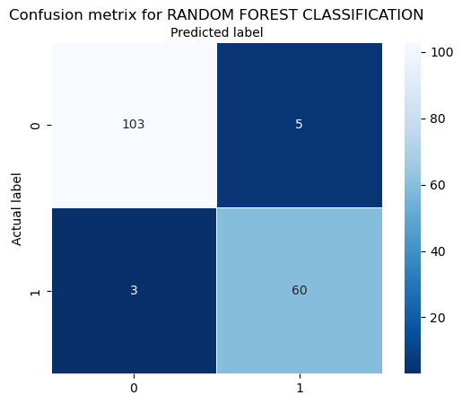

```python
class_names = [0,1]
fig,ax = plt.subplots()
tick_marks = np.arange(len(class_names))
plt.xticks(tick_marks,class_names)
plt.yticks(tick_marks,class_names)
sns.heatmap(RFC_cm, annot = True, fmt = 'g', linewidth = 0.5, square = True, cmap = 'Blues_r')
ax.xaxis.set_label_position("top")
plt.ylabel("Actual label")
plt.xlabel("Predicted label")
plt.title("Confusion metrix for RANDOM FOREST CLASSIFICATION")
plt.show()
```

# confusion matrix

cofusion matrix graph is a graphytational representation that is use to see how the pridiction is, in other to know the type of breast cancer that has the true positive even when new sample is introduced.

```python
RFC_cm = cm(y_test, testPredictions)
RFC_cm
```

```
array([[103,   5],
       [  3,  60]], dtype=int64)
```

# conclusion

From the different algorithims been used to classify the type of breast cancer dataset, Random forest was seen to be the best algorithm because it produces the best accuracy out of others been used (which is 0.953 accuracy i.e 95%). Therefore, Random forest is selected as the best model to classify welther a pacient has breast cancer or not.

```python
trainPredictions = RFCmodel.predict(x_train)
testPredictions = RFCmodel.predict(x_test)
```

```python
#Evaluation

from sklearn import metrics

print ("Accuracy: ", metrics.accuracy_score(y_test, testPredictions))
print ("Precision: ", metrics.precision_score(y_test, testPredictions))
print ("Recall: ", metrics.recall_score(y_test, testPredictions))
```

```
Accuracy:  0.9532163742690059
Precision:  0.9230769230769231
Recall:  0.9523809523809523
```